# TFM - Análisis Empírico

Kamal Romero

Julio de 2017

El modo más habitual que poseen las instituciones de educación superior para cuantificar la labor docente y/o el grado de satisfacción del alumnado es a través de las encuestas de valoración docente. Dicho instrumento esta lejos de ser perfecto y capturar todas las dimensiones tanto de la labor docente como de la relación profesor-alumno, pero por otro lado es un proceso estándar que permite la recolección de mucha información y además es un requisito impuesto por la Agencia Nacional de Evaluación de la Calidad y Acreditación [(ANECA)](http://www.aneca.es/).

Al ser de los pocos elementos cuantitaivos que poseen los centros, estos se emplean como input a la hora de elaborar políticas de mejora de la calidad de la enseñanza así como para evaluar la evolución de las mismas. Es en este sentido que es importante la adecuada interpretación de las encuestas.

En la presente sección se realiza un ejericio empírico empleando los datos de valoraciones de las encuestas, el cual consiste en analizar el efecto de ciertas variables sobre la valoración global. Para ello procedemos en dos pasos: primero realizamos un analísis factorial para reducir la dimensión de los items de valoración (9) y condensarlos en dos factores que interpretamos como *docencia* y *relación alumno-profesor*. Posteriormente empleamos estos factores junto a información del profesorado (sexo, categoría, etc.) y de las asignaturas (cuantitativa vs no-cuantitaiva) como variables explicativas en una regresión logística cuya variable dependiente (target) es la valoración global del profesor.

Lo anterior nos permitirá comprender como afectan las variables postuladas y los factores a los que hemos reducido los items de valoración, a la valoración del profesorado

# 1 Librerías Empleadas

En este ejercicio se emplean las librerías `readr`, `PerformanceAnalytics`, `corrplot`, `REdaS`, `nFactors`, `ggplot2`, `knitr` y `reshape2`

# 2 Carga de Datos

Se fijan el directorio, se cargan los datos y se renombran las columnas

```r
setwd("C:/Users/Usuario/Documents/KSchool/TFM")

encuesta <- read_csv("~/KSchool/TFM/encuesta.csv")
colnames(encuesta) <- c('Division', 'Curso', 'Grupo', 'Asignatura', 'Profesor', 'Item 1', 'Item 2',
                        'Item 3', 'Item 4', 'Item 5', 'Item 6', 'Item 7', 'Item 8', 'Item 9', 'Item 10')
```

# 3 Inspección de los datos

```r
dim(encuesta)
```

```
## [1] 3532   15
```

```r
head(encuesta)
```

```
## # A tibble: 6 × 15
##   Division Curso Grupo Asignatura Profesor `Item 1` `Item 2` `Item 3`
##      <int> <int> <chr>      <int>    <int>    <dbl>    <dbl>    <dbl>
## 1        2     1     A          2        6        5        6        4
## 2        2     1     A          2        6        7        7        6
## 3        2     1     A          2        6       10       10       10
## 4        2     1     A          2        6        8        7        7
## 5        2     1     A          2        6        9        8        8
## 6        2     1     A          2        6        7        8        8
## # ... with 7 more variables: `Item 4` <dbl>, `Item 5` <dbl>, `Item
## #   6` <dbl>, `Item 7` <dbl>, `Item 8` <dbl>, `Item 9` <dbl>, `Item
## #   10` <dbl>
```

```r
tail(encuesta)
```

```
## # A tibble: 6 × 15
##   Division Curso Grupo Asignatura Profesor `Item 1` `Item 2` `Item 3`
##      <int> <int> <chr>      <int>    <int>    <dbl>    <dbl>    <dbl>
## 1        1     5     A        250      223        4        4        4
## 2        1     5     A        250      223        8        8        7
## 3        1     5     A        250      223        5        5        4
## 4        1     5     A        250      223        4        4        4
## 5        1     5     A        250      223        5        4        4
## 6        1     5     A        250      223        7        7        6
## # ... with 7 more variables: `Item 4` <dbl>, `Item 5` <dbl>, `Item
## #   6` <dbl>, `Item 7` <dbl>, `Item 8` <dbl>, `Item 9` <dbl>, `Item
## #   10` <dbl>
```

```r
summary(encuesta)
```

```
##     Division         Curso          Grupo             Asignatura
##  Min.   :1.000   Min.   :1.000   Length:3532        Min.   :  1.0
##  1st Qu.:2.000   1st Qu.:1.000   Class :character   1st Qu.:204.0
##  Median :4.000   Median :2.000   Mode  :character   Median :403.0
##  Mean   :3.054   Mean   :2.213                      Mean   :295.7
##  3rd Qu.:4.000   3rd Qu.:3.000                      3rd Qu.:411.0
##  Max.   :4.000   Max.   :5.000                      Max.   :448.0
##     Profesor         Item 1           Item 2           Item 3
##  Min.   :  1.0   Min.   : 1.000   Min.   : 1.000   Min.   : 1.00
##  1st Qu.:203.0   1st Qu.: 6.000   1st Qu.: 5.000   1st Qu.: 6.00
##  Median :404.0   Median : 8.000   Median : 7.000   Median : 8.00
##  Mean   :292.5   Mean   : 7.557   Mean   : 6.962   Mean   : 7.23
##  3rd Qu.:413.0   3rd Qu.: 9.000   3rd Qu.: 9.000   3rd Qu.: 9.00
##  Max.   :448.0   Max.   :10.000   Max.   :10.000   Max.   :10.00
##      Item 4           Item 5           Item 6           Item 7
##  Min.   : 1.000   Min.   : 1.000   Min.   : 1.000   Min.   : 1.000
##  1st Qu.: 6.000   1st Qu.: 6.000   1st Qu.: 7.000   1st Qu.: 7.000
##  Median : 8.000   Median : 7.000   Median : 9.000   Median : 9.000
##  Mean   : 7.306   Mean   : 7.143   Mean   : 8.325   Mean   : 8.134
##  3rd Qu.: 9.000   3rd Qu.: 9.000   3rd Qu.:10.000   3rd Qu.:10.000
##  Max.   :10.000   Max.   :10.000   Max.   :10.000   Max.   :10.000
##      Item 8           Item 9          Item 10
##  Min.   : 1.000   Min.   : 1.000   Min.   : 1.000
##  1st Qu.: 6.000   1st Qu.: 6.000   1st Qu.: 6.000
##  Median : 8.000   Median : 8.000   Median : 8.000
##  Mean   : 7.646   Mean   : 7.501   Mean   : 7.578
##  3rd Qu.:10.000   3rd Qu.:10.000   3rd Qu.: 9.000
##  Max.   :10.000   Max.   :10.000   Max.   :10.000
```

Creamos una sub-muestra la cual contenga solo los datos correspondientes a las valoraciones de la encuesta. A continuación mostramos la matriz de correlaciones

```r
valoraciones.01 <- encuesta[,6:ncol(encuesta)]

correlacion <- cor(valoraciones.01)
correlacion
```

```
##            Item 1    Item 2    Item 3    Item 4    Item 5    Item 6
## Item 1  1.0000000 0.7831138 0.8197303 0.6478371 0.6081591 0.4460796
## Item 2  0.7831138 1.0000000 0.8045067 0.7107927 0.5824781 0.4204928
## Item 3  0.8197303 0.8045067 1.0000000 0.7027876 0.6356100 0.4367953
## Item 4  0.6478371 0.7107927 0.7027876 1.0000000 0.5862828 0.4393621
## Item 5  0.6081591 0.5824781 0.6356100 0.5862828 1.0000000 0.3930434
## Item 6  0.4460796 0.4204928 0.4367953 0.4393621 0.3930434 1.0000000
## Item 7  0.6458613 0.6147452 0.6364873 0.6990586 0.5526771 0.5191614
## Item 8  0.5326760 0.5121247 0.5290036 0.5122925 0.5124014 0.4929399
## Item 9  0.7300260 0.7898754 0.7597696 0.6589444 0.6051135 0.4372998
## Item 10 0.8079596 0.8090558 0.8305367 0.7372289 0.6854885 0.5073300
##            Item 7    Item 8    Item 9   Item 10
## Item 1  0.6458613 0.5326760 0.7300260 0.8079596
## Item 2  0.6147452 0.5121247 0.7898754 0.8090558
## Item 3  0.6364873 0.5290036 0.7597696 0.8305367
## Item 4  0.6990586 0.5122925 0.6589444 0.7372289
## Item 5  0.5526771 0.5124014 0.6051135 0.6854885
## Item 6  0.5191614 0.4929399 0.4372998 0.5073300
## Item 7  1.0000000 0.6145965 0.6393909 0.7324907
## Item 8  0.6145965 1.0000000 0.5578230 0.6102630
## Item 9  0.6393909 0.5578230 1.0000000 0.8289202
## Item 10 0.7324907 0.6102630 0.8289202 1.0000000
```

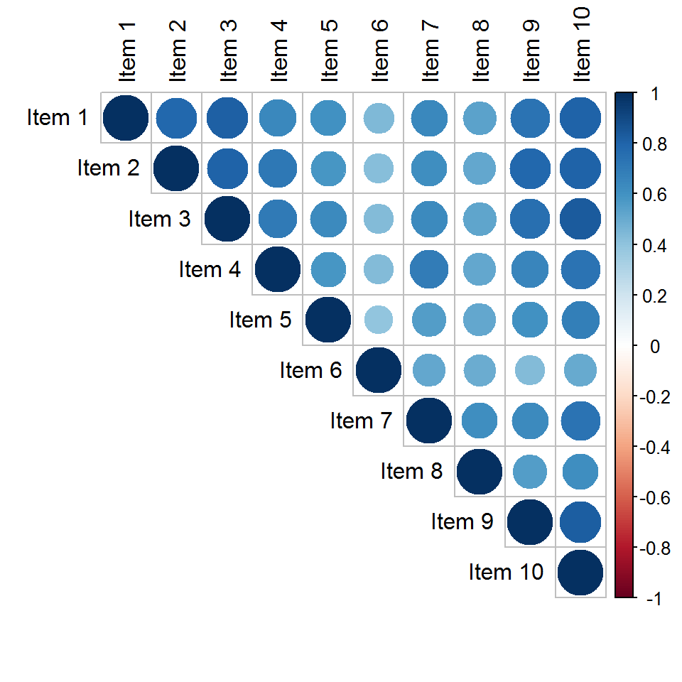

```r
corrplot(correlacion, type = "upper", order = "original",
         tl.col = "black")
```

Miramos las correlaciones excluyendo el item 10, que representa la valoración global del profesor la cual usaremos como variable dependiente en el ejercicio empírico

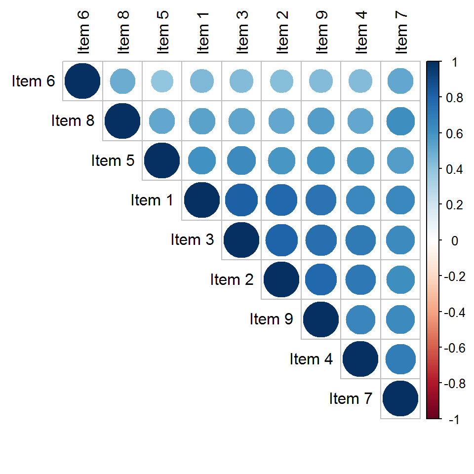

```r
valoraciones.02 <- valoraciones.01[,1:ncol(valoraciones.01)-1]
correlacion2 <- cor(valoraciones.02)
corrplot(correlacion2, type = "upper", order = "hclust",
         tl.col = "black")
```

Observamos los diagramas de cajas e histogramas de los items de valoración

```r
valoraciones.01.flat <- melt(valoraciones.01)
```

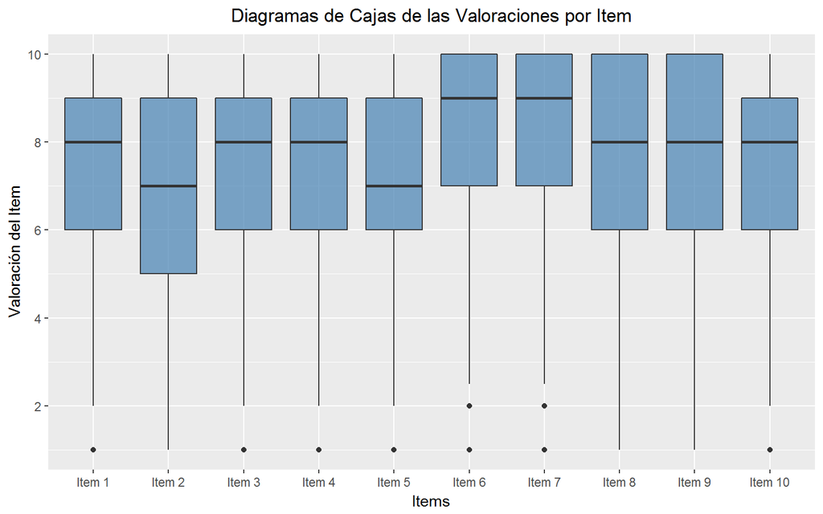

```r
p <- ggplot(valoraciones.01.flat)
p <- p + aes(x=variable, y = value) + geom_boxplot(fill='steelblue', alpha = 0.7)
p <- p + scale_y_continuous(name = "Valoración del Item", breaks = seq(0, 10, 2)) +
  scale_x_discrete(name= "Items")
p <- p + ggtitle("Diagramas de Cajas de las Valoraciones por Item") +
  theme(plot.title = element_text(hjust = 0.5)) #Esto es para centrar el título
p
```

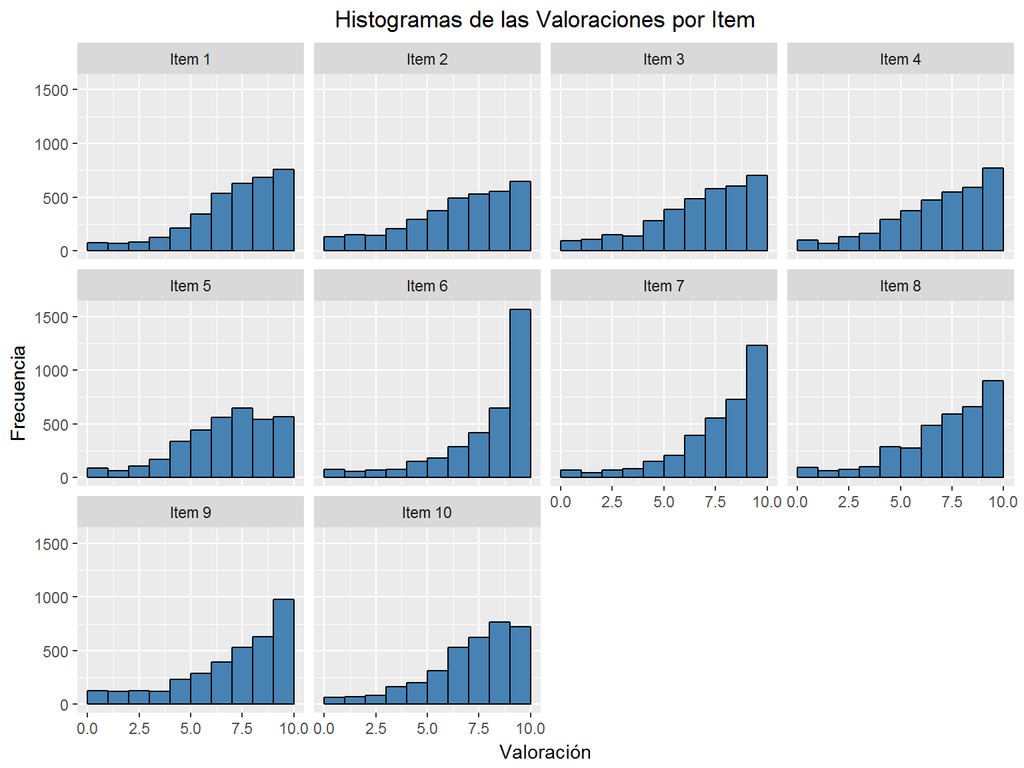

```r
h <- ggplot(valoraciones.01.flat)
h <- h + aes(value)
h <- h + geom_histogram(fill='steelblue', col = 'black', breaks=seq(0, 10, by = 1))
h <- h + facet_wrap(~variable) + ggtitle("Histogramas de las Valoraciones por Item") +
  theme(plot.title = element_text(hjust = 0.5)) #Esto es para centrar el título
h <- h + labs(x="Valoración", y="Frecuencia")
h
```

En los histrogramas destaca el sesgo hacia la derecha que presentan todas las distribuciones de frecuencias. Lo cual es de esperar, ya que la evaluaciones están concentradas en las valoraciones altas y suele haber poca frecuencia de valoraciones muy bajas.

En todos los casos la calificación más frecuente es la máxima (10), excepto en el item 5 (8) y el 10 que representa la valoración global del profesor (9). El item que mayor valoración presenta con diferencia es el 6 (puntualidad)

# 4 Análisis factorial

El análisis factorial se puede interpretar como una técnica de reducción de dimensiones, pero a diferencia del análisis de componentes principales el primero asume un proceso generador de datos como explicaremos más adelante, no explica toda la varianza de la muestra y además se concentra no en la varianza sino en las covarianzas entre las variables.

En el presente trabajo asumimos que grupos de items se mueven en la misma dirección debido a que los mismos evalúan una determinada aptitud o característica común. Lo anterior nos presenta un par de retos, primero debido a la alta correlación entre los items arriba expuesta cualquier ejercicio de regresión genera estimadores no eficientes y por ende los contrastes de hipótesis individual y conjunto de los parámetros no son informativos. Segundo, si consideramos que existen factores comunes no observables que afectan de manera separada a grupos de items generando dicha correlación, podríamos emplear dichos factores comunes en lugar de todos los items.

Por lo anterior realizamos un análisis factorial que nos permita extraer las variables no observables que afectan la covarianza entre items.

Como se menciona arriba el análisis factorial asume un proceso generador de datos, el cual establece que las variables en estudio dependen linealmente de un conjunto de variables no observables o *latentes*. Consideramos un vector de variables observables $x =(x_1,x_2, \ldots , x_p)$ que se encuentran relacionados linealmente con un número de variables latentes $f_1,f_2, \ldots, f_k$ donde $k<p$ de la siguiente forma:

$$\begin{eqnarray}
x_1 = & \mu_1 + \lambda_{11}f_1 + \ldots + \lambda_{1k}f_k + u_1\\
& \vdots \\
x_p = & \mu_2 + \lambda_{p1}f_1 + \ldots + \lambda_{pk}f_k + u_p
\end{eqnarray}$$

representado de modo matricial

$$\mathbf{x} = \mathbf{\mu} + \Lambda\mathbf{f} + \mathbf{u}$$

donde $\mathbf{f}$ es un vector $(k \times 1)$ de variables *latentes* no observadas que llamaremos factores. $\Lambda$ una matriz $(p \times k)$ de parámetros desconocidos y $\mathbf{u}$ un vector $(p \times 1)$ de perturbaciones.

Las expresiones anteriores establecen que los valores observados (en nuestro caso los items de valoración) dependen linealmente de los factores y una perturbación aleatoria que resume el efecto de todas las variables distintas a los factores sobre los valores observados. Como es usual se asume que los errores son independientes entre si y de los factores, y siguen una distribución normal de media cero y varianza constante $N_m(0,\Psi)$. Lo anterior implica que $\Psi$ es una matriz diagonal.

Las constantes de la matriz $\Lambda$ se denominan *cargas* y representan como los factores afectan a las variables observadas. Nos diran por ejemplo si el factor “docencia” ejerece un efecto importantes o no sobre el item 8 por ejemplo. Se asume que las cargas son variables aleatorias que siguen una distribución normal multiviarante estandarizada $N_m(0,\mathbf{I})$.

Dado que $\mathbf{x}$ es una suma de variables normales tiene distribución normal. Dado que la media de los factores y la perturbación es cero la media de $\mathbf{x}$ es $\mathbf{\mu}$, resumiendo $\mathbf{x} \thicksim N_m(\mathbf{\mu},\mathbf{V})$

A partir de lo anterior podemos calcular la varianza de la variable $x_i$:

$$\begin{align}
& Var(x_i) = \lambda_{i1}^2Var(f_1)+ \ldots + \lambda_{ik}^2Var(f_k)+Var(u_i) \\
& Var(x_i) = \sum_{j=1}^{k}\lambda_{ij}^2 + \psi_i
\end{align}$$

La varianza de cada variable observada se puede descomponer en dos partes. $\sum_{j=1}^{k}\lambda_{ij}^2$ se denomina comunalidad y representa aquella parte de la $x_i$ explicada por los factores y por ende la varianza compartida con el resto de las variables. Por su parte $\psi_i$ es la varianza específica y por lo tanto no compartida con las demás variables.

Podemos obtener la matriz de covarianzas entre las observaciones partiendo de su definición $E[(\mathbf{x}-\mathbf{\mu})(\mathbf{x}-\mathbf{\mu})']$, donde $\mathbf{x}-\mathbf{\mu} = \Lambda\mathbf{f} + \mathbf{u}$

$$\begin{align}
E[(\mathbf{x}-\mathbf{\mu})(\mathbf{x}-\mathbf{\mu})'] =& E[(\Lambda\mathbf{f} + \mathbf{u})(\Lambda\mathbf{f} + \mathbf{u})'] \\
E[(\mathbf{x}-\mathbf{\mu})(\mathbf{x}-\mathbf{\mu})'] =& \Lambda E[\mathbf{f}\mathbf{f'}']\Lambda'+
\Lambda E[\mathbf{f}\mathbf{u}']+\Lambda E[\mathbf{f'}\mathbf{u}]+E[\mathbf{u}\mathbf{u}']\\
E[(\mathbf{x}-\mathbf{\mu})(\mathbf{x}-\mathbf{\mu})'] =& \Lambda \Lambda'+E[\mathbf{u}\mathbf{u}']\\
E[(\mathbf{x}-\mathbf{\mu})(\mathbf{x}-\mathbf{\mu})'] =& \Lambda \Lambda'+\mathbf{\psi}
\end{align}$$
donde $\Lambda \Lambda'$ y $\mathbf{\psi}$ representan la comunalidad y varianza específica descrita arriba.

El problema que se plantea el modelo factorial es estimar los parámetros $\hat{\Lambda}$ y $\hat{\mathbf{\psi}}$ a partir de la matriz de covarianzas *muestral* de modo que esta sea lo más próxima posible a la matriz de covarianzas teórica $\Lambda \Lambda'+\mathbf{\psi}$.

Dicha estimación suele hacerse por el método de los factores principales o por máxima verosimilitud, emplearemos esta última este ejercicio.

## 4.1 Contrastes previos a la extracción de factores

El análisis factorial tiene sentido en la medida que las variables en estudio se encuentren altamente correladadas, los tests previos realizan contrastes que permiten contrastar la hipótesis de alta o baja correlación entre las variables

### 4.1.1 Test de Barlett

Asumiendo el caso extremo de ninguna relación entre las variables, la matriz de correlaciones sería una matriz identidad. Es decir, los elementos fuera de la diagonal que representan las correlaciones entre las variables serían iguales a cero, y la diagonal como es habitual igual a uno. En este caso el determinante de la matriz es igual a uno

Partiendo de esto el test de Barlett toma como hipótesis nula que el determinante de la matriz de correlaciones es igual a uno y como alternativa que el mismo es distinto de cero. Bajo la hipótesis nula el estadístico de contraste sigue una distribución chi-cuadrado.

```r
BT <- bartlett.test(valoraciones.02)
BT$statistic
```

```
## Bartlett's K-squared
##             204.2618
```

```r
BT$p.value
```

```
## [1] 8.076886e-40
```

El valor del estadístico es alto y el p-valor cercano a cero, por lo que se rechaza la hipótesis nula de ausencia de correlación entre las variables con un nivel de significación del 1%

### 4.1.2 Test KMO

El siguiente contraste es el test KMO (Kaiser, Meyer y Olkin) o de adecuación muestral, el cual parte de la idea de que #si un cojunto de variables se encuentran altamente relacionadas entre si, sus coeficientes de correlación serán altos mientras que sus coeficientes de correlación parcial (relación entre pares de variables sin tomar en cuenta el efecto del resto de las variables) serán bajos. De ser esto así, las variables comunes (factores) entre las variables serán de importancia

En la literatura varios autores señalan distintas *escalas* de la adecuación de los datos a un estudio factorial según el valor del KMO. Enumeramos las propuesta por Kaiser y citada en la documentación del paquete [REdaS](https://cran.r-project.org/web/packages/REdaS/REdaS.pdf): maravilloso si KMO ≥ 0.9, mieritorio si 0.9 > KMO ≥ 0.8 <; mediano para 0.8 > KMO ≥ 0.7; mediocre para 0.7 > KMO ≥ 0.6; miserable si 0.6 > KMO ≥ 0.5 e inaceptable para KMO < 0.5.

```r
KMO.T <- KMOS(valoraciones.02, use= "pairwise.complete.obs")
KMO.T$KMO
```

```
## [1] 0.9337983
```

El valor del test KMO es de 0.9337983, por lo que nuestra muestra puede ser calificada de adecuada para un análisis factorial

## 4.2 Determinación de los factores

Procedemos a estimar los factores con el uso de la función `factanal` la cual emplea el método de máxima verosimilitud.

Dada la estructura de las preguntas de la encuentas, partimos de la hipótesis de que existen dos factores.

```r
set.seed(123)

fa.valoraciones1 <- factanal(valoraciones.02, factors = 2, rotation = "none", scores = "regression")
fa.valoraciones1$loadings
```

```
##
## Loadings:
##        Factor1 Factor2
## Item 1  0.871  -0.114
## Item 2  0.882  -0.176
## Item 3  0.896  -0.155
## Item 4  0.800   0.119
## Item 5  0.704
## Item 6  0.537   0.298
## Item 7  0.779   0.377
## Item 8  0.649   0.315
## Item 9  0.851
##
##                Factor1 Factor2
## SS loadings      5.517   0.420
## Proportion Var   0.613   0.047
## Cumulative Var   0.613   0.660
```

```r
fa.valoraciones1$uniquenesses
```

```
##    Item 1    Item 2    Item 3    Item 4    Item 5    Item 6    Item 7
## 0.2285090 0.1914755 0.1728763 0.3464977 0.4992957 0.6222856 0.2507069
##    Item 8    Item 9
## 0.4793332 0.2716534
```

```r
fa.valoraciones1$STATISTIC
```

```
## objective
##  496.0537
```

```r
fa.valoraciones1$PVAL
```

```
##    objective
## 3.758585e-93
```

EL primer factor tiene una alta carga en los items 1,2,3 y 9, mientras que el factor 2 no pareciera tener cargas relevantes en ningún item.

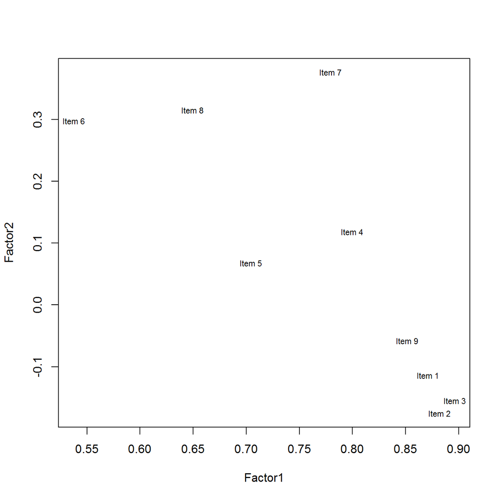

```r
cargas1 <- fa.valoraciones1$loadings[,1:2]
plot(cargas1,type="n")
text(cargas1,labels=names(valoraciones.02),cex=.7)
```

Aplicamos una rotación ortogonal empleando el método Varimax, el cual maximiza la varianza de las cargas al cuadrado de cada factor, de este modo hace que algunas de las cargas sean lo más grandes posibles mientras que el resto sean lo más pequeñas. De este modo obtenemos cargas muy altas en algunos items y casi nulas en otros.

```r
fa.valoraciones2 <- factanal(valoraciones.02, factors = 2, rotation = "varimax")
fa.valoraciones2$loadings
```

```
##
## Loadings:
##        Factor1 Factor2
## Item 1 0.770   0.422
## Item 2 0.815   0.379
## Item 3 0.815   0.404
## Item 4 0.576   0.568
## Item 5 0.529   0.470
## Item 6 0.258   0.558
## Item 7 0.407   0.764
## Item 8 0.338   0.638
## Item 9 0.721   0.456
##
##                Factor1 Factor2
## SS loadings      3.399   2.538
## Proportion Var   0.378   0.282
## Cumulative Var   0.378   0.660
```

```r
fa.valoraciones2$uniquenesses
```

```
##    Item 1    Item 2    Item 3    Item 4    Item 5    Item 6    Item 7
## 0.2285090 0.1914755 0.1728763 0.3464977 0.4992957 0.6222856 0.2507069
##    Item 8    Item 9
## 0.4793332 0.2716534
```

```r
fa.valoraciones2$STATISTIC
```

```
## objective
##  496.0537
```

```r
fa.valoraciones2$PVAL
```

```
##    objective
## 3.758585e-93
```

Ahora el factor 1 sigue teniendo cargas altas en los items 1, 2, 3 y 9 aunque el peso del item 1 ha disminuido. Por su parte el factor 2 ha incrementado basante sus cargas en ciertos items, retiene el item 6 y presenta saturaciones altas en los items 7 y 8.

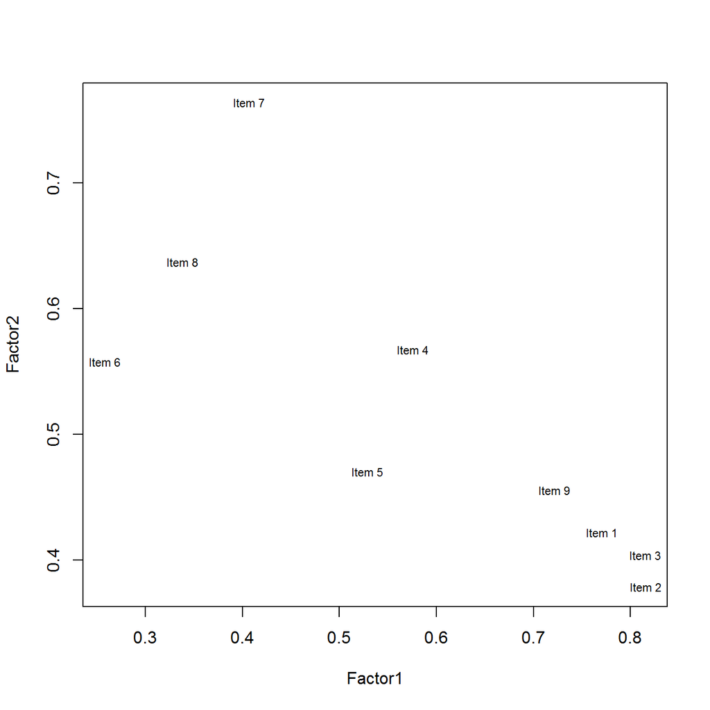

```r
cargas2 <- fa.valoraciones2$loadings[,1:2]
plot(cargas2,type="n")
text(cargas2,labels=names(valoraciones.02),cex=.7)
```

Se empieza a visualizar nuestra hipótesis de partida de dos factores que representen los aspectos docentes de la asignatura (items 1, 2, 3 y 9) y la relación alumno-profesor (items 6, 7 y 8). Podríamos considerar el item 4 como una mezcla de ambos, mientras que no queda claro donde incluir el item 5 aunque presenta un sesgo hacia la opción docente.

Ahora realizamos una rotación oblicua, la cual a diferencia de la ortogonal permite cierta correlación entre los factores. Se emplea el método Promax

```r
fa.valoraciones3 <- factanal(valoraciones.02, factors = 2, rotation = "promax")
fa.valoraciones3$loadings
```

```
##
## Loadings:
##        Factor1 Factor2
## Item 1  0.785   0.114
## Item 2  0.886
## Item 3  0.865
## Item 4  0.387   0.466
## Item 5  0.396   0.351
## Item 6          0.667
## Item 7          0.877
## Item 8          0.733
## Item 9  0.688   0.197
##
##                Factor1 Factor2
## SS loadings      2.932   2.146
## Proportion Var   0.326   0.238
## Cumulative Var   0.326   0.564
```

```r
fa.valoraciones3$uniquenesses
```

```
##    Item 1    Item 2    Item 3    Item 4    Item 5    Item 6    Item 7
## 0.2285090 0.1914755 0.1728763 0.3464977 0.4992957 0.6222856 0.2507069
##    Item 8    Item 9
## 0.4793332 0.2716534
```

```r
fa.valoraciones3$STATISTIC
```

```
## objective
##  496.0537
```

```r
fa.valoraciones3$PVAL
```

```
##    objective
## 3.758585e-93
```

Como era de esperarse ahora tenemos saturaciones más claras, en este caso refuerzan las conclusiones de la rotación ortogonal.

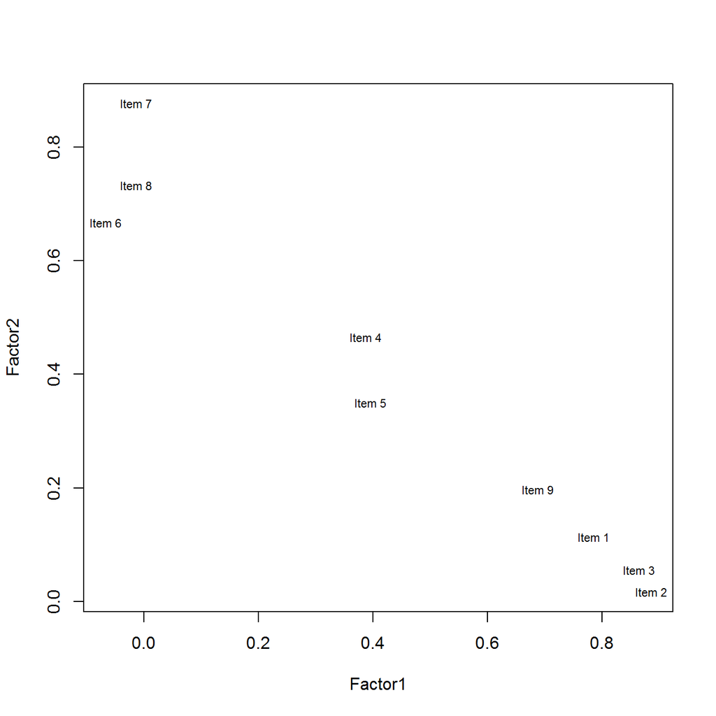

```r
cargas3 <- fa.valoraciones3$loadings[,1:2]
plot(cargas3,type="n")
text(cargas3,labels=names(valoraciones.02),cex=.7)
```

En el gráfico se observa una separación más clara entre los items que corresponden a cada factor, los correespondientes a la labor docente y a la relación profesor alumno.